# Generalized Competing Event Modeling with gcemod

gcemod

## What gcemod does

`gcemod` estimates covariate effects on **omega+** — the ratio of the hazard for an *event of interest* to the hazard for a *competing event* — on either the cause-specific (Cox) or subdistribution (Fine-Gray) scale. Confidence intervals and p-values come from the **Lunn-McNeil** stacked-model construction. Per-subject omega = omega+/(1+omega+) is reported as a descriptive quantity so model-predicted values can be compared with observed ones.

The workflow: (1) fit the GCE model, (2) build a risk score, (3) find cutpoints that maximize the omega+ difference between groups, (4) draw alligator plots of cumulative incidence by group, and (5) check calibration of predicted vs. observed omega+.

## Two contrasting cohorts

The package bundles two competing-risks example datasets that illustrate contrasting GCE applications. They are provided for illustration only and do not represent real patients. In `hn` (head and neck) the event of interest (cancer recurrence) is *more* frequent than the competing event (omega+ > 1). In `prostate` the event of interest (distant metastasis or prostate-cancer death) is *less* frequent than the competing event (other-cause death) (omega+ < 1). Both use `status`: 0 = censored, 1 = event of interest, 2 = competing event, with `time` in years.

```r
data(hn)
Ind <- data.frame(event     = as.integer(hn$status == 1),   # recurrence
                  competing = as.integer(hn$status == 2))   # death w/o recurrence
Cov <- hn[, c("age", "smoker", "t_cat", "n_cat", "p16")]
```

### 1. Fit the GCE model (cause-specific)

```r
fit <- gcecox(hn$time, Ind, Cov, M = 5, t = 5)
summary(fit)
```

```
#> Generalized competing event model [Cox (cause-specific)]
#> Call: gcecox(Time = hn$time, Ind = Ind, Cov = Cov, M = 5, t = 5)
#>   n = 1000;  events of interest = 391;  competing events = 243;  t = 5
#>
#> --- omega+ ratio (event of interest vs. competing event) ---
#>        exp(coef) (omega+ ratio) lower .95 upper .95 P-value
#> age                     0.93295   0.91310   0.95323 0.00000
#> smoker                  0.71795   0.49232   1.04697 0.08516
#> t_cat2                  1.00580   0.40885   2.47437 0.98995
#> t_cat3                  0.80732   0.33493   1.94596 0.63349
#> t_cat4                  0.90705   0.37726   2.18085 0.82747
#> n_cat1                  1.26583   0.71349   2.24574 0.42031
#> n_cat2                  1.30179   0.84012   2.01715 0.23788
#> n_cat3                  0.91398   0.47167   1.77110 0.78987
#> p16                     0.64152   0.38994   1.05542 0.08053
#>
#> Lunn-McNeil omnibus test: chi-sq = 49.215, df = 9, p = <1e-04
```

Each `P-value` tests whether that covariate shifts omega+ (event of interest vs. competing event); the omnibus test asks the same jointly.

The Fine-Gray version uses the same interface:

```r
fit_fg <- gcefg(hn$time, Ind, Cov, M = 5, t = 5)
summary(fit_fg)
```

### 2. Risk score

The linear predictor is stored in `fit$riskscore`, and per-subject omega+ / omega at time `t` in `fit$omegaplus` / `fit$omega`.

```r
head(data.frame(riskscore = fit$riskscore,
                omegaplus = fit$omegaplus, omega = fit$omega))
```

```
#>    riskscore omegaplus     omega
#> 1  0.3111360 2.4611482 0.7110785
#> 2  1.6653168 9.5334700 0.9050645
#> 3  0.5548256 3.1402976 0.7584715
#> 4 -0.5955188 0.9939913 0.4984933
#> 5 -0.1996211 1.4767900 0.5962516
#> 6  0.4918702 2.9486935 0.7467517
```

### 3. Cutpoints maximizing the omega+ difference

```r
cuts <- gce_cutpoints(fit, groups = 2, method = "optimal")
cuts$summary
```

```
#>   group   n events_of_interest competing_events mean_omegaplus mean_omega
#> 1   Low 484                181              167       1.105913  0.5070653
#> 2  High 516                210               76       3.396035  0.7458401
```

```r
cuts$cutpoints
```

```
#> [1] -0.02022627
```

### 4. Alligator plot (cumulative incidence by risk group)

Risk groups are distinguished by color and event types by line type (event of interest solid, competing event dashed) on a single panel.

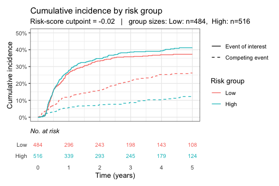

```r
gce_alligator(fit, groups = cuts)
```

### 5. Calibration of predicted vs. observed omega+

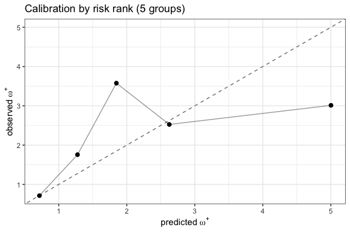

```r
gce_calibration(fit, which = "omegaplus", groups = 5)
```

### Discrimination

```r
gce_performance(fit)
```

```
#> C-index (event of interest): 0.502 (95% CI 0.471-0.532)  [risk-score orientation flipped]
```

## The competing-dominant contrast: prostate

Running the same workflow on `prostate` shows the opposite regime. Here the competing event (other-cause death) dominates, so omega+ ratios and the risk score point the other way, and the alligator jaws open with the competing-event CIF on top.

```r
data(prostate)
Ind_p <- data.frame(event     = as.integer(prostate$status == 1),
                    competing = as.integer(prostate$status == 2))
Cov_p <- prostate[, c("age", "psa", "gleason", "t2b", "comorbidity")]

fit_p <- gcecox(prostate$time, Ind_p, Cov_p, M = 5, t = 5)
summary(fit_p)
gce_alligator(fit_p, groups = 2)
```

## References

Lunn M, McNeil D (1995) Applying Cox regression to competing risks. *Biometrics* 51:524–32.

Carmona R, et al. (2014) Validated competing event model for the stage I-II endometrial cancer population. *Int J Radiat Oncol Biol Phys* 89:888–98.

Carmona R, et al. (2016) Improved method to stratify elderly patients with cancer at risk for competing events. *J Clin Oncol* 34:1270–77.

Mell LK, et al. (2019) Nomogram to predict the benefit of intensive treatment for locoregionally advanced head and neck cancer. *Clin Cancer Res* 25:7078–7088.

Zakeri K, et al. (2020) Predictive classifier for intensive treatment of head and neck cancer. *Cancer* 126:5263–5273.

Mell LK, et al. (2024) Effects of androgen deprivation therapy on prostate cancer outcomes according to competing event risk. *Eur Urol* 85:373–381.